# Case study: a real multi-donor, multi-cell-type cohort (GEO GSE60424)

The other vignettes use small synthetic tables. This one walks through a real public cohort whose metadata has exactly the kind of structure that makes naive random splits leak, and shows what splitGraph’s validation, derivation, and `split_spec` look like on it.

## The data

GEO series GSE60424 is an RNA-seq study of whole blood and six sorted immune cell populations from 20 donors: healthy controls and patients with type 1 diabetes, amyotrophic lateral sclerosis, sepsis, or multiple sclerosis. The sample-level metadata (not the expression data) ships with splitGraph as `inst/extdata/GSE60424_samples.csv`; `inst/extdata/GSE60424_README.md` records how it was derived from the GEO `characteristics` fields.

```r
path <- system.file("extdata", "GSE60424_samples.csv", package = "splitGraph")
gse <- read.csv(path, stringsAsFactors = FALSE)
str(gse)
```

```
#> 'data.frame':    134 obs. of  12 variables:
#>  $ geo_accession  : chr  "GSM1479501" "GSM1479502" "GSM1479503" "GSM1479500" ...
#>  $ sample_id      : chr  "20_Bcells" "20_CD4T" "20_CD8T" "20_Monocytes" ...
#>  $ subject_id     : chr  "D20" "D20" "D20" "D20" ...
#>  $ cell_type      : chr  "B-cells" "CD4" "CD8" "Monocytes" ...
#>  $ disease_status : chr  "Healthy Control" "Healthy Control" "Healthy Control" "Healthy Control" ...
#>  $ collection_date: chr  "January 25 2012" "January 25 2012" "January 25 2012" "January 25 2012" ...
#>  $ sex            : chr  "F" "F" "F" "F" ...
#>  $ library_index  : int  4 5 27 2 1 11 6 7 12 13 ...
#>  $ condition      : chr  "Healthy Control" "Healthy Control" "Healthy Control" "Healthy Control" ...
#>  $ timepoint_id   : chr  "baseline" "baseline" "baseline" "baseline" ...
#>  $ time_index     : int  0 0 0 0 0 0 0 0 0 0 ...
#>  $ batch_id       : chr  "2012-01-25" "2012-01-25" "2012-01-25" "2012-01-25" ...
```

Three facts about its structure drive everything below:

```r
# 1. Every donor contributed six or seven samples, one per cell population
#    that was successfully sorted for them.
range(table(gse$subject_id))
```

```
#> [1] 6 7
```

```r
table(table(gse$subject_id))
```

```
#>
#>  6  7
#>  6 14
```

```r
# 2. Every donor was collected on its own date, so collection date (the natural
#    "batch") coincides with donor.
all(tapply(gse$batch_id, gse$subject_id, function(x) length(unique(x))) == 1)
```

```
#> [1] TRUE
```

```r
# 3. Every donor has exactly one disease status.
all(tapply(gse$condition, gse$subject_id, function(x) length(unique(x))) == 1)
```

```
#> [1] TRUE
```

One caveat about the labels: GEO records multiple sclerosis samples as “pretreatment” or “posttreatment” under six distinct `donorid` values (`D31`, `D45`, `D55` for `pre_treatment` and `D33`, `D46`, `D56` for `post_treatment`). Under the raw `subject_id` column, each draw ID appears at only one label:

```r
with(gse[gse$condition == "MS", ], table(subject_id, timepoint_id))
```

```
#>           timepoint_id
#> subject_id post_treatment pre_treatment
#>        D31              0             6
#>        D33              6             0
#>        D45              0             7
#>        D46              7             0
#>        D55              0             6
#>        D56              7             0
```

However, the GEO study protocol states that blood was drawn from MS patients before and 24 hours after their first interferon-beta treatment, and the collection dates (`2012-05-21`/`22` for `D31`/`D33`, `2012-06-28`/`29` for `D45`/`D46`, and `2012-08-23`/`24` for `D55`/`D56`) and sex (`F`) are consistent with three putative pre/post patient pairs. Below we first build the graph from the as-recorded `subject_id` column (20 draw IDs) and then show how mapping those putative pairs (or linking them with must-link edges) yields 17 putative patient groups.

## Build the graph

Sorted cell populations are a categorical compartment of the sample, which is what splitGraph’s `Region` node type represents; disease status is the outcome. `columns =` maps the CSV names onto the canonical ones.

```r
meta <- gse[, c("sample_id", "subject_id", "batch_id", "cell_type", "condition", "sex")]
g <- graph_from_metadata(
  meta,
  columns = c(region_id = "cell_type", outcome_id = "condition"),
  graph_name = "GSE60424"
)
g
```

```
#> <dependency_graph> GSE60424
#>   Nodes: 186
#>   Edges: 536
```

```r
summary(g)$node_types
```

```
#>     value   n
#> 1  Sample 134
#> 2   Batch  20
#> 3 Subject  20
#> 4  Region   7
#> 5 Outcome   5
```

At 186 nodes this is past the size where drawing the whole graph tells you anything. `focus = "ego"` is the view for a graph like this: it zooms to one node’s neighbourhood, so you can check a single donor’s structure instead of squinting at the cohort. Two hops out from donor `D20` reach its samples, and through them the cell populations, collection date and disease status those samples carry:

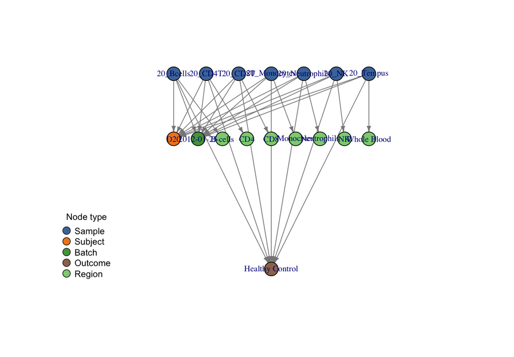

```r
plot(g, focus = "ego", node = "subject:D20", order = 2,
     legend_position = "bottomleft")
```

## What validation says

```r
report <- validate_graph(g)
report
```

```
#> <depgraph_validation_report>  GSE60424
#>   Valid: TRUE
#>   Issues: 20
#>   By severity:
#>    - advisory : 20
```

```r
summary(report)$by_code
```

```
#>                      value  n
#> 1 repeated_subject_samples 20
```

Twenty `repeated_subject_samples` advisories, one per donor: every donor is linked to several samples, so any split that treats samples as independent will put the same person on both sides. Nothing rises above advisory, and the report is short for two different reasons worth separating.

The cross-study and cross-site rules cannot fire because this graph has no `Study` or `Site` nodes at all — the CSV carries neither, so those axes simply do not exist here. `heavy_batch_reuse` does not fire because no batch holds half the cohort: each collection date covers one donor’s six or seven samples.

There is also no rule for a donor spanning several *regions*, and in this cohort every donor spans six or seven of them. That is deliberate rather than an oversight: one person contributing several sorted cell populations is the design of the experiment, not an anomaly. The advisory that a donor has several samples already carries the leakage signal; which compartments those samples came from is information for the split, not a finding against the data.

## How much would a naive split leak?

A plain random five-fold assignment of the 134 samples, without splitGraph:

```r
set.seed(1)
fold <- sample(rep(1:5, length.out = nrow(gse)))
straddling <- tapply(fold, gse$subject_id, function(f) length(unique(f)) > 1)
sum(straddling)
```

```
#> [1] 20
```

20 of 20 donors would appear in more than one fold. A model evaluated that way sees each test donor’s other cell populations during training.

## Derive constraints

```r
by_subject <- derive_split_constraints(g, mode = "subject")
by_batch   <- derive_split_constraints(g, mode = "batch")
by_region  <- derive_split_constraints(g, mode = "region")
c(subject = by_subject$metadata$n_groups,
  batch   = by_batch$metadata$n_groups,
  region  = by_region$metadata$n_groups)
```

```
#> subject   batch  region
#>      20      20       7
```

Because collection date and donor coincide, the batch partition *is* the subject partition. Two groupings with different labels but the same partition compare equal under a canonical relabelling:

```r
canon <- function(x) as.integer(match(x, unique(x)))
identical(canon(grouping_vector(by_subject)), canon(grouping_vector(by_batch)))
```

```
#> [1] TRUE
```

The region partition is a different animal, and it is worth seeing why it is the wrong split unit here even though it is a perfectly valid one. Grouping by cell population cuts the cohort *across* donors rather than between them, so every donor lands in six or seven different groups — the exact leak the study is exposed to:

```r
region_groups <- grouping_vector(by_region)
donor_spread <- tapply(region_groups[gse$sample_id], gse$subject_id,
                       function(x) length(unique(x)))
range(donor_spread)
```

```
#> [1] 6 7
```

```r
sum(donor_spread > 1)   # donors split across more than one region group
```

```
#> [1] 20
```

Which is why region travels on the spec as a blocking annotation below, not as `group_var`. The same column can be the right answer or the wrong one depending on what has to generalise; the graph makes the difference inspectable rather than a matter of taste.

### Composite grouping and over-merging

Six of the seven cell populations were sorted for all twenty donors. That is enough for a strict composite over subject **and** region to chain the entire cohort into one component — donor A’s B-cells link to every other donor’s B-cells, which link to their own other populations, and so on until nothing is left to split.

```r
strict <- derive_split_constraints(g, mode = "composite", via = c("subject", "region"))
strict$metadata$n_groups
```

```
#> [1] 1
```

```r
strict$metadata$warnings
```

```
#> character(0)
```

The empty warning vector is the part to notice. One group covering all 134 samples is a correct answer to the question that was asked, and `splitGraph` does not flag it, so on a composite derivation read `metadata$n_groups` yourself before going further. `detect_dependency_components()` shows it coming before you derive anything:

```r
comps <- detect_dependency_components(g, via = c("Subject", "Region"))
table(as.data.frame(comps)$component_size)
```

```
#>
#> 134
#> 134
```

A single component of 134 — the cohort has no internal boundary along those two relations together.

The rule-based strategy does not chain relations. With subject first in the priority order, every sample has a subject, so region is never consulted and the grouping is the subject partition, with region kept as an annotation:

```r
ruled <- derive_split_constraints(
  g, mode = "composite", strategy = "rule_based",
  via = c("subject", "region"), priority = c("subject", "region")
)
ruled$metadata$n_groups
```

```
#> [1] 20
```

```r
head(as.data.frame(ruled)[, c("sample_id", "group_id", "constraint_type")], 3)
```

```
#>   sample_id              group_id constraint_type
#> 1 20_Bcells composite_subject:D20         subject
#> 2   20_CD4T composite_subject:D20         subject
#> 3   20_CD8T composite_subject:D20         subject
```

### Feasibility comparison and bridge diagnostics

Instead of checking each mode by hand, `compare_split_constraints()` evaluates all candidate modes side by side. Notice `min_stratum_groups = 3`: because the smallest disease strata (`ALS` and `Sepsis`) contain only 3 donors each, a 5-fold donor-grouped split (`k = 5`) cannot place every disease class into every test fold, even though 20 total donors satisfy `k_fold_feasible = TRUE` for unstratified 5-fold grouping. For multi-class stratified evaluation across all five conditions, `k = 3L` (3-fold CV) is the maximum fold count that guarantees at least one donor per disease class in every fold:

```r
cmp <- compare_split_constraints(g, k = 3L)
cmp
```

```
#> <split_constraint_comparison> (k = 3 folds)
#>       mode strategy n_samples n_groups max_group_size max_group_share
#>    subject  subject       134       20              7      0.05223881
#>      batch    batch       134       20              7      0.05223881
#>     region   region       134        7             20      0.14925373
#>  composite   strict       134        1            134      1.00000000
#>  effective_n_groups singleton_share k_fold_feasible n_risks_severed
#>           19.906874               0            TRUE              20
#>           19.906874               0            TRUE              20
#>            6.916795               0            TRUE               0
#>            1.000000               0           FALSE               0
#>  n_risks_remaining min_stratum_groups
#>                  0                  3
#>                  0                  3
#>                 20                  7
#>                 20                  1
```

Both `subject` and `batch` report `n_risks_severed = 20` because collection date is nested 1-to-1 within donor on this cohort (so grouping by `batch` empirically keeps every donor’s samples together, even though `batch` mode does not semantically enforce subject separation in general cohorts). Meanwhile, `composite` (`strategy = "strict"`) collapses all 134 samples into `n_groups = 1` (`k_fold_feasible = FALSE`), which cannot form a train/test split and therefore reports `n_risks_severed = 0`.

To also prevent the three putative pre/post MS patient pairs (`D31`/`D33`, `D45`/`D46`, `D55`/`D56`) from straddling folds without re-importing `g`, we can add synthetic must-link edges via `relatedness_edges_from_kinship()` (using `0.5`, the theoretical self/duplicate kinship value on the KING scale, as a must-link weight rather than an empirical genotype estimate), yielding 17 putative patient groups with `min_stratum_groups = 3`:

```r
ms_pairs <- data.frame(
  id1 = c("D31", "D45", "D55"),
  id2 = c("D33", "D46", "D56"),
  kinship = c(0.5, 0.5, 0.5),
  stringsAsFactors = FALSE
)
g_paired <- add_edges(
  g,
  relatedness_edges_from_kinship(ms_pairs, threshold = 0.25)
)
compare_split_constraints(g_paired, modes = c("subject", "relatedness"), k = 3L)
```

```
#> <split_constraint_comparison> (k = 3 folds)
#>         mode    strategy n_samples n_groups max_group_size max_group_share
#>      subject     subject       134       20              7      0.05223881
#>  relatedness relatedness       134       17             14      0.10447761
#>  effective_n_groups singleton_share k_fold_feasible n_risks_severed
#>            19.90687               0            TRUE              20
#>            15.53287               0            TRUE              20
#>  n_risks_remaining min_stratum_groups
#>                  0                  3
#>                  0                  3
```

When a composite derivation over-merges, `find_dependency_bridges()` ranks the non-sample entities by how many connected components would be gained (or how much the largest component would shrink) if each entity were removed:

```r
bridges <- find_dependency_bridges(g, via = c("Subject", "Region"), top_n = 7L)
as.data.frame(bridges)[, c("node_id", "node_type", "n_samples_linked",
                           "n_components_before", "n_components_without",
                           "is_bridge")]
```

```
#>              node_id node_type n_samples_linked n_components_before
#> 1     region:B-cells    Region               20                   1
#> 2         region:CD4    Region               20                   1
#> 3         region:CD8    Region               20                   1
#> 4   region:Monocytes    Region               20                   1
#> 5 region:Neutrophils    Region               20                   1
#> 6 region:Whole Blood    Region               20                   1
#> 7          region:NK    Region               14                   1
#>   n_components_without is_bridge
#> 1                    1     FALSE
#> 2                    1     FALSE
#> 3                    1     FALSE
#> 4                    1     FALSE
#> 5                    1     FALSE
#> 6                    1     FALSE
#> 7                    1     FALSE
```

Every `Region` node links 14 to 20 samples across donors; removing any single cell population still leaves the other six cell populations chaining all 20 donors into a single component (`n_components_without = 1`), confirming that `Region` is a cohort-wide cross-cutting factor rather than a single-node bridge.

## The split_spec

Grouping by subject is the right primary constraint here; batch and region travel as blocking annotations and the disease status as the stratum (the default `stratify_by = "outcome"`; pass `stratify_by = "region"` or `"none"` to populate `stratum` from a blocking axis or omit it).

```r
spec <- as_split_spec(by_subject, graph = g)
spec
```

```
#> <split_spec> subject
#>   Samples: 134
#>   Groups: 20
#>   Block vars: batch_group, region_group
#>   Stratum var: stratum
#>   Recommended resampling: grouped_cv
```

```r
spec$block_vars
```

```
#> [1] "batch_group"  "region_group"
```

```r
spec$stratum_var
```

```
#> [1] "stratum"
```

```r
head(as.data.frame(spec)[, c("sample_id", "group_id", "batch_group", "region_group", "stratum")], 7)
```

```
#>        sample_id    group_id batch_group region_group         stratum
#> 1      20_Bcells subject:D20  2012-01-25      B-cells Healthy Control
#> 2        20_CD4T subject:D20  2012-01-25          CD4 Healthy Control
#> 3        20_CD8T subject:D20  2012-01-25          CD8 Healthy Control
#> 4   20_Monocytes subject:D20  2012-01-25    Monocytes Healthy Control
#> 5 20_Neutrophils subject:D20  2012-01-25  Neutrophils Healthy Control
#> 6          20_NK subject:D20  2012-01-25           NK Healthy Control
#> 7      20_Tempus subject:D20  2012-01-25  Whole Blood Healthy Control
```

```r
validate_split_spec(spec)
```

```
#> <split_spec_validation>
#>   Valid: TRUE
#>   Issues: 0
```

The leakage summary marks which of the validation findings this constraint structurally severs:

```r
risks <- summarize_leakage_risks(g, constraint = by_subject, split_spec = spec)
unique(as.data.frame(risks)[, c("category", "severity", "severed")])
```

```
#>                    category severity severed
#> 1  repeated_subject_samples advisory    TRUE
#> 21         split_spec_ready advisory      NA
#> 22       blocking_available advisory      NA
```

A consumer that groups on `group_id` and stratifies on `stratum` (for example scikit-learn’s `StratifiedGroupKFold` through the shipped Python reader, or bioLeak’s `as_leaksplits()`) will now keep every donor’s cell populations on one side of each fold while keeping the five conditions represented in every fold as far as 20 donors allow.

## Working with a subset

Restricting the analysis to, say, healthy controls and multiple sclerosis patients is a graph operation, not a re-import:

```r
keep <- gse$sample_id[gse$condition %in% c("Healthy Control", "MS")]
g_sub <- subset_graph(g, samples = keep, graph_name = "GSE60424: HC vs MS")
summary(g_sub)$node_types
```

```
#>     value  n
#> 1  Sample 67
#> 2   Batch 10
#> 3 Subject 10
#> 4  Region  7
#> 5 Outcome  2
```

```r
spec_sub <- as_split_spec(derive_split_constraints(g_sub, "subject"), graph = g_sub)
table(spec_sub$sample_data$stratum)
```

```
#>
#> Healthy Control              MS
#>              28              39
```

## Handing off

```r
out <- tempfile(fileext = ".json")
write_split_spec(spec, out)
validate_split_spec_json(out)$valid
```

```
#> [1] TRUE
```

```r
unlink(out)
```

The JSON carries the grouping, the blocking columns, the stratum, and the provenance (`metadata$relations_used`, `splitgraph_version`, `derived_at`), so the decision “one donor never straddles a fold” is recorded once and can be executed anywhere.